# Population Genetic Structure Part 2 of 2

#### 5.4. DAPC based Jenkins et al., 2019

```r
# Run a DAPC using site IDs as priors

milkfish_genind$pop
```

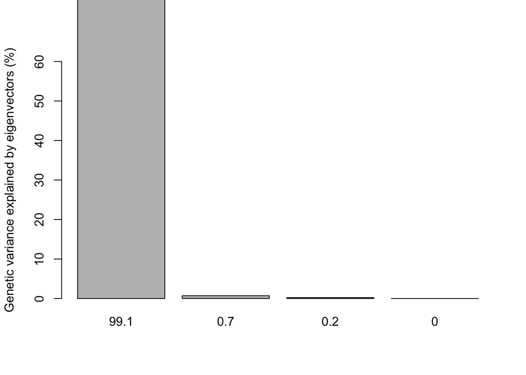

```r
milkfish_genind@pop <- as.factor(pop_vector)

dapc1 <- dapc.genind(milkfish_genind, pop = pop_vector, n.pca = 70, n.da = 3)


# Analyse how much percent of genetic variance is explained by each axis
percent = dapc1$eig/sum(dapc1$eig)*100
barplot(percent, ylab = "Genetic variance explained by eigenvectors (%)", ylim = c(0,60),
        names.arg = round(percent, 1))
```

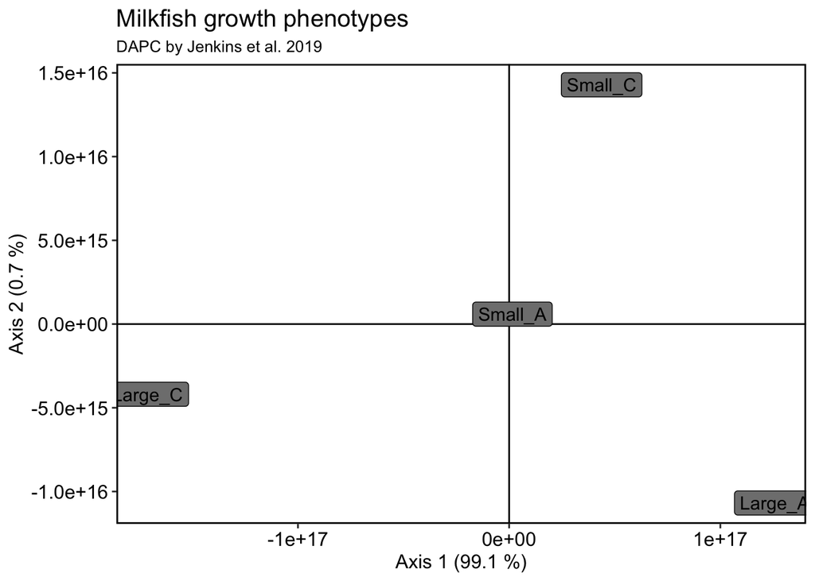

```r
# Create a data.frame containing individual coordinates
ind_coords = as.data.frame(dapc1$ind.coord)

# Rename columns of dataframe
colnames(ind_coords) = c("Axis1","Axis2","Axis3")

# Add a column containing individuals
ind_coords$Ind = indNames(milkfish_genind)

# Add a column with the site IDs
ind_coords$Site = milkfish_genind$pop

# Add regional labels to data frame
ind_coords = add_region_labs(ind_coords)

# Calculate centroid (average) position for each population
centroid = aggregate(cbind(Axis1, Axis2, Axis3) ~ Site, data = ind_coords, FUN = mean)
centroid = add_region_labs(centroid)
centroid$Region = factor(centroid$Region, levels = region_order)

# Add centroid coordinates to ind_coords dataframe
ind_coords = left_join(ind_coords, centroid, by = "Site", suffix = c("",".cen"))
ind_coords$Region = factor(ind_coords$Region, levels = region_order)

# Custom x and y labels
xlab = paste("Axis 1 (", format(round(percent[1], 1), nsmall=1)," %)", sep="")
ylab = paste("Axis 2 (", format(round(percent[2], 1), nsmall=1)," %)", sep="")

# Scatter plot axis 1 vs. 2
dapc_plt1 = ggplot(data = ind_coords, aes(x = Axis1*-1, y = Axis2))+
  geom_hline(yintercept = 0)+
  geom_vline(xintercept = 0)+
  # spider segments
  geom_segment(aes(xend = Axis1.cen*-1, yend = Axis2.cen, colour = Region), show.legend = FALSE)+
  # points
  geom_point(aes(fill = Region), shape = 21, size = 3, show.legend = FALSE)+
  # centroids
  geom_label(data = centroid, aes(label = Site, fill = Region), size = 4, show.legend = FALSE)+
  # colouring
  scale_fill_manual(values = cols)+
  scale_colour_manual(values = cols)+
  # custom labels
  labs(x = xlab, y = ylab)+
  ggtitle("Milkfish growth phenotypes", subtitle = "DAPC by Jenkins et al. 2019")+
  # custom theme
  ggtheme
dapc_plt1
```

```r
# Export plot (optional)
#ggsave(plot = dapc_plt1, filename = "Lobster_DAPC_70_PCs.png", width = 12, height = 8, dpi = 600)
```

Now we will perform DAPC method based on a recent study by Thia 2022

## DAPC: K-1 Method in Thia 2022

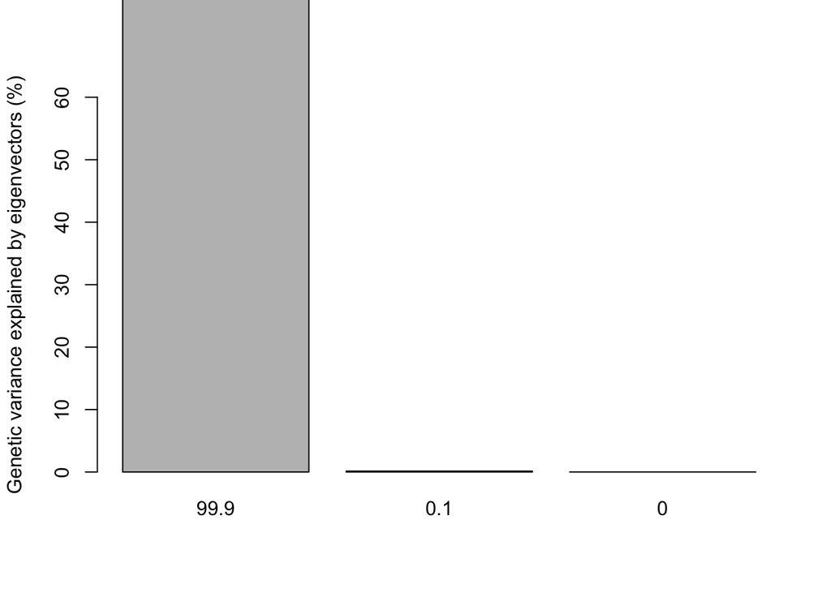

```r
# Run a DAPC using site IDs as priors
dapc2 = dapc(milkfish_genind, milkfish_genind$pop, n.pca = 4, n.da = 3)

# Analyse how much percent of genetic variance is explained by each axis
percent = dapc2$eig/sum(dapc2$eig)*100
barplot(percent, ylab = "Genetic variance explained by eigenvectors (%)", ylim = c(0,60),
        names.arg = round(percent, 1))
```

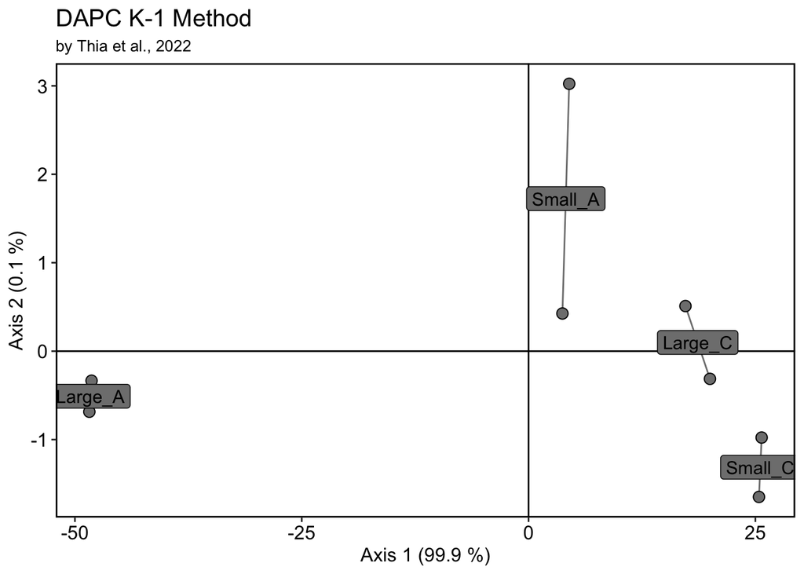

```r
# Create a data.frame containing individual coordinates
ind_coords = as.data.frame(dapc2$ind.coord)

# Rename columns of dataframe
colnames(ind_coords) = c("Axis1","Axis2","Axis3")

# Add a column containing individuals
ind_coords$Ind = indNames(milkfish_genind)

# Add a column with the site IDs
ind_coords$Site = milkfish_genind$pop

# Add regional labels to data frame
ind_coords = add_region_labs(ind_coords)

# Calculate centroid (average) position for each population
centroid = aggregate(cbind(Axis1, Axis2, Axis3) ~ Site, data = ind_coords, FUN = mean)
centroid = add_region_labs(centroid)
centroid$Region = factor(centroid$Region, levels = region_order)

# Add centroid coordinates to ind_coords dataframe
ind_coords = left_join(ind_coords, centroid, by = "Site", suffix = c("",".cen"))
ind_coords$Region = factor(ind_coords$Region, levels = region_order)

# Custom x and y labels
xlab = paste("Axis 1 (", format(round(percent[1], 1), nsmall=1)," %)", sep="")
ylab = paste("Axis 2 (", format(round(percent[2], 1), nsmall=1)," %)", sep="")

# Scatter plot axis 1 vs. 2
dapc_plt2 = ggplot(data = ind_coords, aes(x = Axis1, y = Axis2))+
  geom_hline(yintercept = 0)+
  geom_vline(xintercept = 0)+
  # spider segments
  geom_segment(aes(xend = Axis1.cen, yend = Axis2.cen, colour = Region), show.legend = FALSE)+
  # points
  geom_point(aes(fill = Region), shape = 21, size = 3, show.legend = FALSE)+
  # centroids
  geom_label(data = centroid, aes(label = Site, fill = Region), size = 4, show.legend = FALSE)+
  # colouring
  scale_fill_manual(values = cols)+
  scale_colour_manual(values = cols)+
  # custom labels
  labs(x = xlab, y = ylab)+
  ggtitle("DAPC K-1 Method", subtitle = "by Thia et al., 2022")+
  # custom theme
  ggtheme
dapc_plt2
```

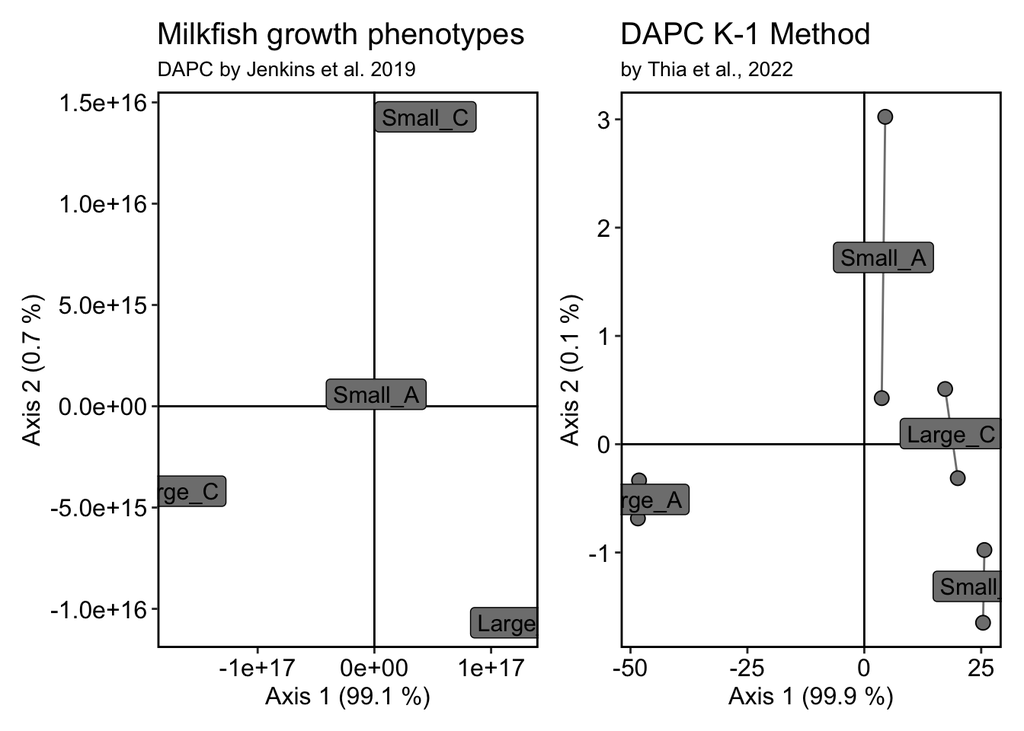

```r
# Export plot
#ggsave(plot = dapc_plt2, filename = "Milkfish_DAPC_4_PCs.png", width = 12, height = 8, dpi = 600)


## Combine plots
##If you want to combine two plots
#install.packages("patchwork")
library(patchwork) # v1.1.1
(dapc_fig = dapc_plt1 + dapc_plt2)
```

```r
#ggsave(plot = dap)
```

#### What do you observed based on the results of the two plots?

We can see that using all the PC’s and using only few PC’s do have significant difference with the structure. Whats consistent about these two plots is that each regional cluster / populations are separated from one another and that majority of the variance is explained by Axis 1 (99.1 % vs 99.9%).

#### Which one reflects the correct multidimensional clustering / groupings?

## Co-ancestry matrix plot

FineRADStructure - Full tutorial here [https://www.milan-malinsky.org/fineradstructure]

Understanding of shared ancestry in genetic datasets is often key to their interpretation. The fineSTRUCTURE package (Lawson et al., 2012) represents a powerful model-based approach to investigating population structure using genetic data. It offers especially high resolution in inference of recent shared ancestry (see e.g. the genetic structure of the British population in Leslie et al., 2015). The high resolution of this method derives from: a) utilizing haplotype linkage information and b) focusing on the most recent coalescence (common ancestry) among the sampled individuals to derive a “co-ancestry matrix” - a summary of nearest neighbor haplotype relationships in the dataset. Further advantages when compared with other model-based methods (e.g. STRUCTURE and ADMIXTURE) include the ability to deal with a very large number of populations, explore relationships between them, and to quantify ancestry sources in each population.

The fineSTRUCTURE pipeline was designed to meet the needs of analyzing large scale SNP datasets, where chromosomal location of the markers are known and haplotypes are typically assumed to be correctly phased. Therefore, these methods have so far been inaccessible to users without high quality genome-wide haplotypes.

RADpainter is a program designed specifically to infer the co-ancestry matrix from RAD-seq data, taking full advantage of its unique features. We package this program together with the fineSTRUCTURE MCMC clustering algorithm into fineRADstructure - a complete, easy to use, and fast population inference package for RAD-seq data.

### Notes: Requires biallelic nuclear SNPs, filtered out for DP3, GQ20, het excess, maf, miss20

### 1. Install software

```bash
git clone https://github.com/millanek/fineRADstructure
cd fineRADstructure
./configure
make
```

### 2. Create a bash script to run file manipulation prior to the actual fineRADstructure analysis

```bash
#!/bin/bash

./RADpainter hapsFromVCF -p Nproportions_atl.txt milkfish_filtered_PrunedUnrel_vcf.vcf.gz > milkfish_filtered_PrunedUnrel_vcf.haps.txt 2>milkfish_filtered_PrunedUnrel_vcf.haps.out
```

### 2.1. Output

Generating a haplotype file for RADpainter with variants from: milkfish_filtered_PrunedUnrel_vcf.vcf.gz numSamples: 8 Strongly negative inbreeding coefficient; Variant: 0 295642 F = -0.333333 Strongly negative inbreeding coefficient; Variant: 0 445341 F = -0.333333 Strongly negative inbreeding coefficient; Variant: 0 389902 F = -0.333333 Strongly negative inbreeding coefficient; Variant: 0 5502 F = -0.6 Strongly negative inbreeding coefficient; Variant: 0 97614 F = -0.333333 Strongly negative inbreeding coefficient; Variant: 0 5589 F = -0.333333 Missing alleles total: 1419; 0.068564% of total alleles Due to missing genotypes: 1377; 0.970402% of missing Due to too many Ns in the individual: 42; 0.0295983% of missing Due to multiple unphased hets: 0; 0% of missing DONE!

### 3. Check on Nproportions.txt which have high missingness and should be excluded: more than 0.15 mean prroportion of Ns

### 3.1. Exclude the individuals with bcftools

bcftools view -s ^Lbul_AMT24_18_10,Lbul_NIC8_S2C3-4_05 ../14-Lbul_qualityfiltering/Lbul-atl_genotypes_snps.hf.DP3.GQ20.miss20.maf0.01_hwe.nucl

```bash
bcftools view -s ^Indv_01,Indv_02,Indv_03,etc .. milkfish_filtered_PrunedUnrel_vcf.vcf.gz -o milkfish_filtered_PrunedUnrel_removed.vcf.gz
```

### 4. Count the number of SNPs included in this file

```bash
bcftools view milkfish_filtered_PrunedUnrel_removed.vcf.gz -h z | grep contig| wc -l #2717, but maybe not updated
```

### 5. Convert vcf file to .haps

```bash
/home/apl/NAS_apl/milkfish/plink/fineRADstructure/RADpainter hapsFromVCF milkfish_filtered_PrunedUnrel_removed.vcf.gz > milkfish_filtered_PrunedUnrel_removed.haps.txt 2>milkfish_filtered_PrunedUnrel_removed.vcf.gz.haps.out
```

```bash
/home/apl/NAS_apl/milkfish/plink/fineRADstructure/RADpainter paint milkfish_filtered_PrunedUnrel_removed.vcf.haps.txt
```

### 6. Count the number of contigs to include

```bash
wc -l milkfish_filtered_PrunedUnrel_removed.vcf.haps.tx
```

### 7. Print missingness per individual

```bash
less  milkfish_filtered_PrunedUnrel_removed.vcf.haps_missingness.out
```

### 8. Run Finestructure to generate .xml file

```bash
./finestructure -x 100000 -y 100000 -z 1000 milkfish_filtered_PrunedUnrel_removed.vcf.haps_chunks.out milkfish_filtered_PrunedUnrel_removed.vcf.haps_mcmc.xml
```

### 9. Run Finestructure to generate .Treexml file

```bash
./finestructure -m T -x 10000 milkfish_filtered_PrunedUnrel_removed.vcf.haps_chunks.out milkfish_filtered_PrunedUnrel_removed.vcf.haps_mcmc.xml milkfish_filtered_PrunedUnrel_removed.vcf.haps_mcmcTree.xml
```

### 10. Download the file for plotting

First look at the file `fineRADstructurePlot.r`. Open it in R studio. You will see that you need to fill-in the files needed to run the `fineRADStructurePlot.r`.

You basically need three files: First is the `.chunks.out`, Second, `_mcmc.xml`, Third, `_mcmcTree.xml`

Before downloading those files in your computer. You need to make sure the these three files are compatible with what is needed by `fineRADStructurePlot.r`

You need to rename all the files with *chunks* with the word renamed at the start and ***change the population and individual ID so that the names do not contain any symbols such as `-` or `_`. If it contains those symbols `fineRADSTructurePlot.r` would fail.

How to do that? Do a forloop!

```bash
#!/bin/bash

for file in $(ls milkfish_filtered_PrunedUnrel_removed.vcf.haps_chunks.*)
do
   awk 'NR==FNR {a[$1]=$2;next} {for ( i in a) gsub(i,a[i])}1' rename_fineradstructure_atl.txt $file > "renamed_${file}"
done
```

Then you are now ready to download the file. Download the three files listed above using `sftp`

Once you have downloaded the file. You can now open `fineRADstructureplot.R` in R studio and start filling in the details

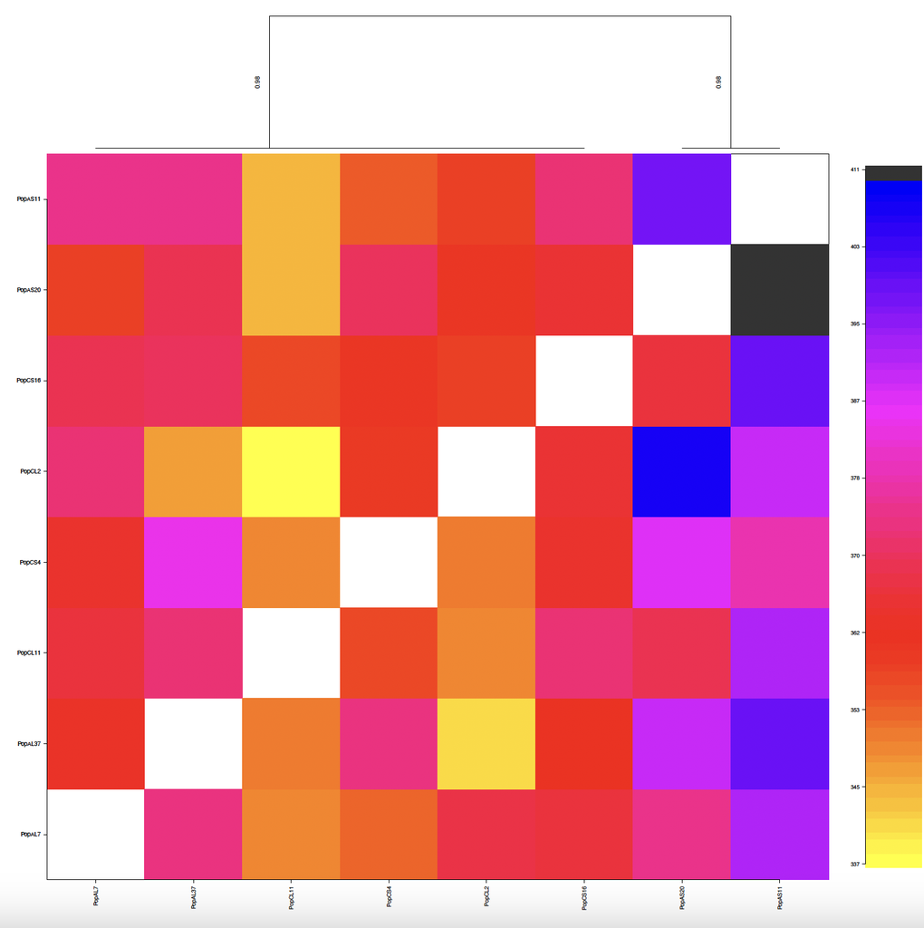

Fig 1. CO-ANCESTRY MATRIX PLOT .

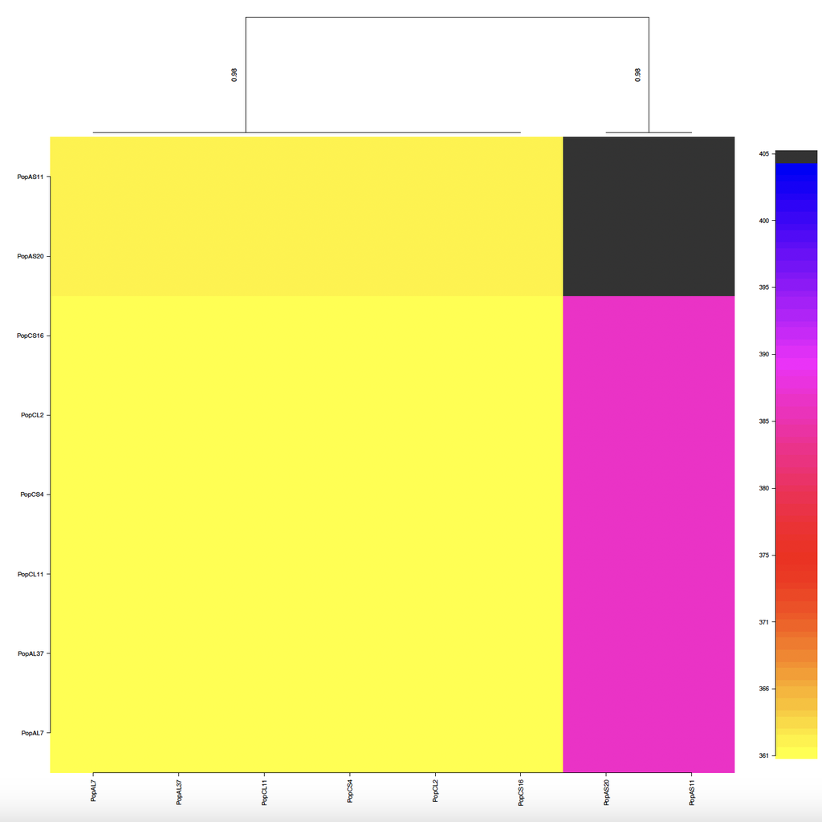

Fig 2.POPULATIONS AND COANCESTRY AVERAGES WITH MORE INFORMATIVE LABELS.

```r
##################################################################
## A simple R example for plotting fineRADstructure output
## Author: Milan Malinsky (millanek@gmail.com), adapted from a Finestructure R Example by Daniel Lawson (dan.lawson@bristol.ac.uk) and using his library of R functions
## Date: 04/04/2016
## Notes:
##    These functions are provided for help working with fineSTRUCTURE output files
## but are not a fully fledged R package for a reason: they are not robust
## and may be expected to work only in some specific cases - often they may require
## at least minor modifications! USE WITH CAUTION!
## SEE FinestrictureLibrary.R FOR DETAILS OF THE FUNCTIONS
##
## Licence: GPL V3
##
##    This program is free software: you can redistribute it and/or modify
##    it under the terms of the GNU General Public License as published by
##    the Free Software Foundation, either version 3 of the License, or
##    (at your option) any later version.

##    This program is distributed in the hope that it will be useful,
##    but WITHOUT ANY WARRANTY; without even the implied warranty of
##    MERCHANTABILITY or FITNESS FOR A PARTICULAR PURPOSE.  See the
##    GNU General Public License for more details.

##    You should have received a copy of the GNU General Public License
##    along with this program.  If not, see <http://www.gnu.org/licenses/>.


### 1) EDIT THE FOLLOWING THREE LINES TO PROVIDE PATHS TO THE fineRADstructure OUTPUT
setwd("/Users/apollo/Documents/Popgen_Workshop/Day_003") ## The directory where the files are located
chunkfile<-"renamed_milkfish_filtered_PrunedUnrel_vcf.haps_chunks.out" ## RADpainter output file
mcmcfile<-"renamed_milkfish_filtered_PrunedUnrel_vcf.haps_chunks.mcmc.xml" ## finestructure mcmc file
treefile<-"renamed_milkfish_filtered_PrunedUnrel_vcf.haps_chunks.mcmcTree.xml" ## finestructure tree file
### 2) EDIT THIS PATH TO WHERE YOU WANT THE PLOTS:
plotsFolder <- "/Users/apollo/Documents/Popgen_Workshop/Day_003"
### 3) SET VALUES FOR THESE VARIABLES: "analysisName" will be included in output plots
analysisName <- "milkfish_8_indvs_Large_Small_2pops";  maxIndv <- 10000; maxPop<-10000

install.packages("XML")
library("XML")


### 4) EDIT THE PATH TO YOUR COPY of FinestructureLibrary.R
source("/Users/apollo/Documents/Popgen_Workshop/Day_003/FinestructureLibrary.R", chdir = TRUE) # read in the R functions, which also calls the needed packages

### 5) EXECUTE THE CODE ABOVE AND THE REST OF THE CODE BELOW
## make some colours
some.colors<-MakeColorYRP() # these are yellow-red-purple
some.colorsEnd<-MakeColorYRP(final=c(0.2,0.2,0.2)) # as above, but with a dark grey final for capped values
###### READ IN THE CHUNKCOUNT FILE
dataraw<-as.matrix(read.table(chunkfile,row.names=1,header=T,skip=1)) # read in the pairwise coincidence
###### READ IN THE MCMC FILES
mcmcxml<-xmlTreeParse(mcmcfile) ## read into xml format
mcmcdata<-as.data.frame.myres(mcmcxml) ## convert this into a data frame
###### READ IN THE TREE FILES
treexml<-xmlTreeParse(treefile) ## read the tree as xml format
ttree<-extractTree(treexml) ## extract the tree into ape's phylo format



## Reduce the amount of significant digits printed in the posteror assignment probabilities (numbers shown in the tree):
ttree$node.label[ttree$node.label!=""] <-format(as.numeric(ttree$node.label[ttree$node.label!=""]),digits=2)
 # convert to dendrogram format
tdend<-myapetodend(ttree,factor=1)
tdend
## Now we work on the MAP state
mapstate<-extractValue(treexml,"Pop") # map state as a finestructure clustering
mapstatelist<-popAsList(mapstate) # .. and as a list of individuals in populations
popnames<-lapply(mapstatelist,NameSummary) # population names IN A REVERSIBLE FORMAT (I.E LOSSLESS)



## NOTE: if your population labels don't correspond to the format we used (NAME<number>) YOU MAY HAVE TROUBLE HERE. YOU MAY NEED TO RENAME THEM INTO THIS FORM AND DEFINE YOUR POPULATION NAMES IN popnamesplot BELOW
popnamesplot<-lapply(mapstatelist,NameMoreSummary) # a nicer summary of the populations
names(popnames)<-popnamesplot # for nicety only
names(popnamesplot)<-popnamesplot # for nicety only
popdend<-makemydend(tdend,mapstatelist) # use NameSummary to make popdend
popdend<-fixMidpointMembers(popdend) # needed for obscure dendrogram reasons
popdendclear<-makemydend(tdend,mapstatelist,"NameMoreSummary")# use NameMoreSummary to make popdend
popdendclear<-fixMidpointMembers(popdendclear) # needed for obscure dendrogram reasons




########################
## Plot 1: COANCESTRY MATRIX
fullorder<-labels(tdend) # the order according to the tree
datamatrix<-dataraw[fullorder,fullorder] # reorder the data matrix

print(rownames(dataraw))  # Check row names
print(colnames(dataraw))  # Check column names
print(fullorder)           # Check fullorder


tmpmat<-datamatrix
tmpmat[tmpmat>maxIndv]<-maxIndv #  # cap the heatmap
pdf(file=paste(plotsFolder,analysisName,"-SimpleCoancestry.pdf",sep=""),height=25,width=25)
plotFinestructure(tmpmat,dimnames(tmpmat)[[1]],dend=tdend,cols=some.colorsEnd,cex.axis=1.1,edgePar=list(p.lwd=0,t.srt=90,t.off=-0.1,t.cex=1.2))
dev.off()



########################
## Plot 2: POPULATIONS AND COANCESTRY AVERAGES
popmeanmatrix<-getPopMeanMatrix(datamatrix,mapstatelist)

tmpmat<-datamatrix
tmpmat[tmpmat>maxIndv]<-maxIndv #  # cap the heatmap
pdf(file=paste(plotsFolder,analysisName,"-SimpleCoancestry.pdf",sep=""),height=25,width=25)
plotFinestructure(tmpmat,dimnames(tmpmat)[[1]],dend=tdend,cols=some.colorsEnd,cex.axis=1.1,edgePar=list(p.lwd=0,t.srt=90,t.off=-0.1,t.cex=1.2))
dev.off()


########################
## Plot 3: POPULATIONS AND COANCESTRY AVERAGES WITH PERHAPS MORE INFORMATIVE LABELS
mappopcorrectorder<-NameExpand(labels(popdend))
mappopsizes<-sapply(mappopcorrectorder,length)
labellocs<-PopCenters(mappopsizes)
xcrt=0
ycrt=45

pdf(file=paste(plotsFolder,analysisName,"-PopAveragedCoancestry2.pdf",sep=""),height=25,width=25)
plotFinestructure(tmpmat,dimnames(tmpmat)[[1]],labelsx=labels(popdendclear),labelsatx=labellocs,xcrt=xcrt,cols=some.colorsEnd,ycrt=ycrt,dend=tdend,cex.axis=1.1,edgePar=list(p.lwd=0,t.srt=90,t.off=-0.1,t.cex=1.2),hmmar=c(3,0,0,1))
dev.off()
```

Here, I have only plotted two figures.